# Mapping of raw reads to RAD loci

J. Ignacio Lucas Lledó

2025-03-17

## Mapping reads to RAD loci

```bash
FASTQDIR=../2023-05-17b/crepi_edits
if [ ! -e radloci.fa.fai ]; then
   if [ ! -e radloci.fa ]; then
      cp ../2024-10-03/consensus.fa ./radloci.fa
   fi
   samtools faidx radloci.fa
fi
if [ ! -e radloci.fa.bwt.2bit.64 ]; then
   bwa-mem2 index radloci.fa &> /dev/null
fi
if [ ! -e samples.txt ]; then
   gawk '(NR > 1){
      gsub(/"/,"",$3)
      print substr($3,1,7)
   }' ../../data/IDs/Crepido_fish_IDs_all_data_2021Dec.txt | \
   sort | uniq > samples.txt
fi

if [ ! -d BAM ]; then mkdir BAM; fi
for SAMPLE in $(cat samples.txt); do
   if [ ! -e BAM/${SAMPLE}.bam ]; then
      if [ ! -e BAM/${SAMPLE}.sam ]; then
         bwa-mem2 mem -t 12 radloci.fa \
            $FASTQDIR/${SAMPLE}.trimmed_R1_.fastq.gz \
            $FASTQDIR/${SAMPLE}.trimmed_R2_.fastq.gz \
            -R "@RG\tID:${SAMPLE}\tSM:${SAMPLE}" 1> BAM/${SAMPLE}.sam 2>> bwamem2.log
      fi
      # Exclude (-F) unmapped reads (4) and secondary alignments (256).
      samtools view -F 260 -u BAM/${SAMPLE}.sam | \
      samtools sort > BAM/${SAMPLE}.bam
      samtools index BAM/${SAMPLE}.bam
      if [ -e BAM/${SAMPLE}.sam ]; then rm BAM/${SAMPLE}.sam; fi
   fi
done
```

## Summary of results

I want to reproduce a figure like the first one in `2024-10-03`, with current mappings, to show the number of loci where at least *N* individuals have any coverage.

```bash
if [ ! -e coverage_matrix.txt ]; then
   N=$(grep "^>" radloci.fa | wc -l)
   if [ ! -e rownames.txt ]; then
      echo "" > rownames.txt
      for i in $(seq 0 $(( N - 1 ))); do
         printf "loc%07i\n" $i >> rownames.txt
      done
   fi
   for i in $(cat samples.txt); do
      sdiff rownames.txt <(samtools view BAM/$i.bam | cut -f 3 | uniq) | \
      gawk -v SAMPLE=$i '(NR == 1){
         print SAMPLE
      }(NR > 1){
         if ($2 ~ /^loc/) {
            print 1
         } else {
            print 0
         }
      }' > z_$i.txt
   done
   paste rownames.txt z_* > coverage_matrix.txt
   rm rownames.txt z_*
fi
```

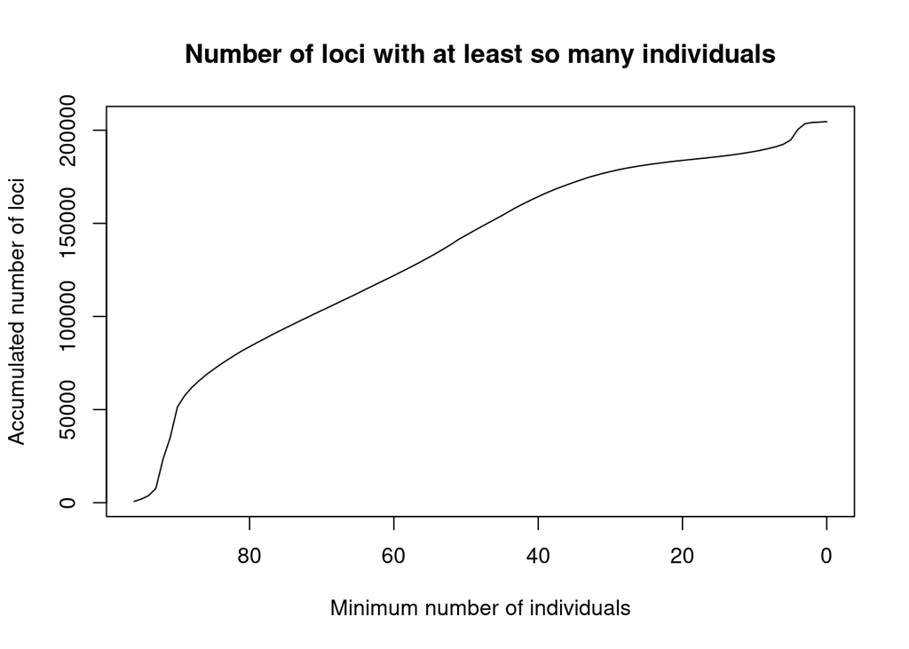

```r
covMat <- read.table('coverage_matrix.txt')
PerLocus <- rowSums(covMat)
PerLocusTab <- as.data.frame(table(PerLocus), stringsAsFactors = FALSE)
names(PerLocusTab) <- c('NumInd', 'NumLoci')
PerLocusTab$NumInd <- as.integer(PerLocusTab$NumInd)
PerLocusTab <- PerLocusTab[order(PerLocusTab$NumInd, decreasing = TRUE),]
PerLocusTab$CumSum <- cumsum(PerLocusTab$NumLoci)
plot(PerLocusTab$NumInd, PerLocusTab$CumSum,
     xlim = c(max(PerLocusTab$NumInd), min(PerLocusTab$NumInd)), type = 'l',
     xlab = 'Minimum number of individuals',
     ylab = 'Accumulated number of loci',
     main = 'Number of loci with at least so many individuals')
```

## May we remove any individual from analysis?

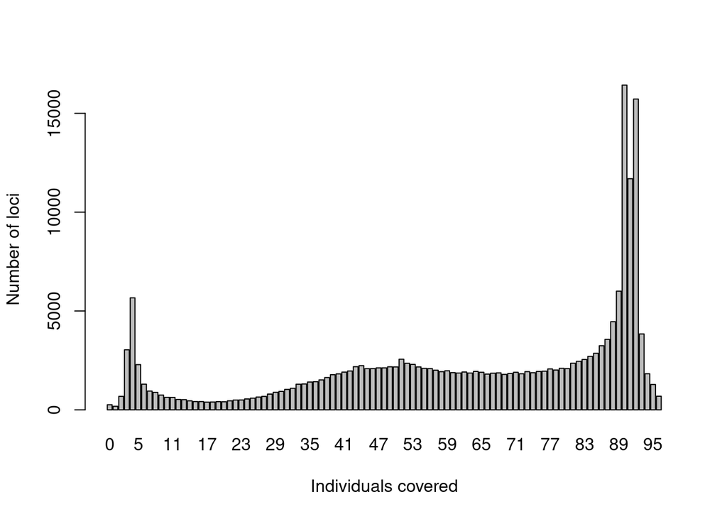

```r
barplot(table(PerLocus), xlab = 'Individuals covered', ylab = 'Number of loci')
```

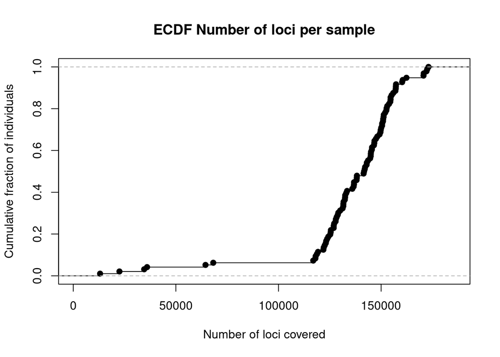

```r
plot(ecdf(colSums(covMat)), xlab = 'Number of loci covered', ylab = 'Cumulative fraction of individuals', main = 'ECDF Number of loci per sample')
```

There are a few samples with less than 100000 loci covered: N044Cx2, N048Cma, N048Cmb, N048Cmc, S031Cmc, T165Cxa. There are also 261 loci not covered by any read in any sample. These are strange: mapping failure? Below I create a list of *bad guys* to be removed from analysis and a list of *good loci* with at least 5 samples. I need it for ANGSD, with the colon after the name of the locus.

```r
write.table(names(which(colSums(covMat) < 100000)),
            file = 'BadGuys.txt', quote = FALSE,
            col.names = FALSE, row.names = FALSE)
covMat2 <- covMat[, colSums(covMat) >= 100000]
write.table(paste0(names(which(rowSums(covMat2) >= 5)), ":"),
            file = 'GoodLoci.txt', quote = FALSE,
            col.names = FALSE, row.names = FALSE)
covMat2 <- covMat2[rowSums(covMat2) >= 5,]
```

## Conclusions

Most loci are covered in less than 80 individuals (out of 96), but there are more than 60000 loci covered at least by one read in more than 80 individuals, and that’s the low-coverage kind of data that ANGSD can help us with. Let’s run it, in a new folder.

I selected a subset of 90 individuals and 190266 loci.